# PS03: Hedonic House Price Regression

ANSWER KEY

2024-07-18

## README

This answer key is only meant as a guideline of grading expectations. Many of these questions are open-ended and so your answers will differ from this key depending on your choice of variables, etc. The written answers here are just the minimal details I look for in answers. An answer should include additional explanation than what is shown here to demonstrate that you fully understand and can communicate the basic statistics.

## Question 1

### **1a:** What patterns do you see in the distribution of house prices? *(10 pts)*

*4 points* for working code and readable figure

*6 points* for written response to the prompt

- could mention the range of prices observed, where the bulk of the distribution is, skew, etc.

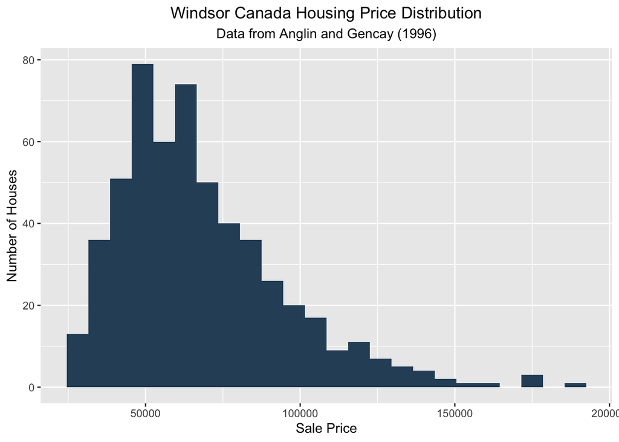

```r
# pricing histogram with custom labels and theme
HousePrices %>%
  ggplot(aes(x=price)) +
  geom_histogram(
    fill = "#2D4F67", # Set a custom color by hex code
    binwidth = 7000   # set a custom width of the bars
    ) +
  labs( # set custom labels for title, x axis, and y axis
    title = "Windsor Canada Housing Price Distribution",
    subtitle = "Data from Anglin and Gencay (1996)",
    x = "Sale Price",
    y = "Number of Houses"
  ) +
  theme( # center title text
    plot.title = element_text(hjust = 0.5),
    plot.subtitle = element_text(hjust = 0.5)
    )
```

### **1b:** Describe the variable you chose. What are the units? Is it continuous or discrete? *(6 pts)*

- Answer will depend on variable chosen. `lotsize` is the only variable which describes a continuous measure (area), `bedrooms`, `bathrooms`, `stories`, `garage`, are all integer values representing counts of each type of space. `recreation`, `fullbase`, `gasheat`, `aircon`, `prefer`, are all qualitative which take on binary value `'yes'` (or `'no'`) in the presence (or absence) of each type of house attribute.

Example with the continuous variable, `lotsize`:

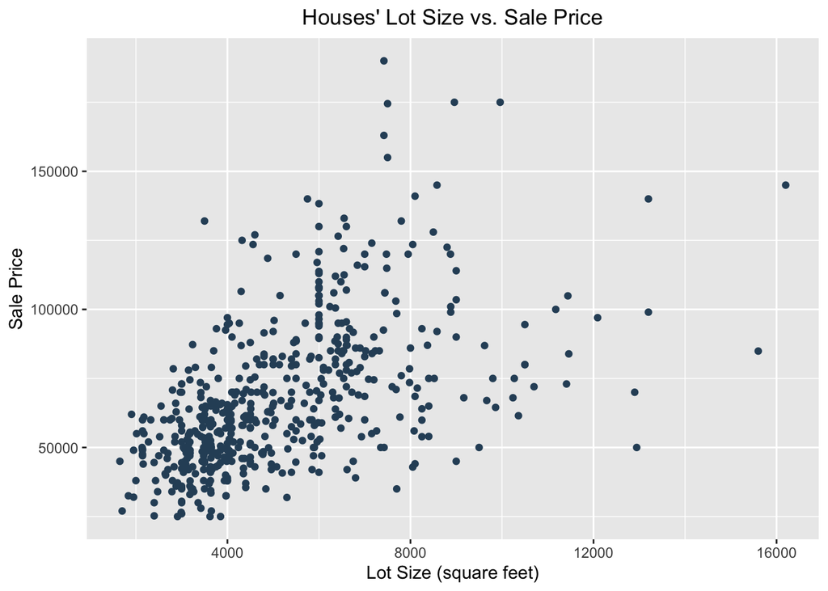

```r
HousePrices %>%
  ggplot(aes( x = lotsize, y = price )) +
  geom_point(color = "#2D4F67") + # set custom dot color
  labs( # set custom labels for title, x axis, and y axis
    title = "Houses' Lot Size vs. Sale Price",
    x = "Lot Size (square feet)",
    y = "Sale Price"
  ) +
  theme( plot.title = element_text(hjust = 0.5) ) # center title text
```

Example with a discrete variable, `bedrooms`:

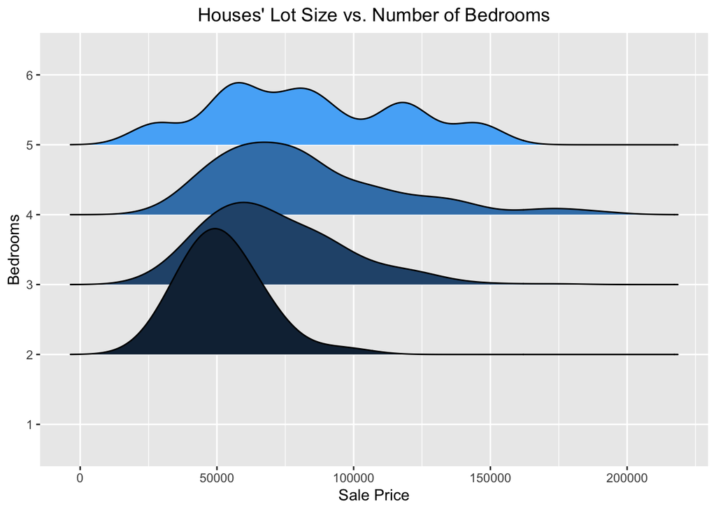

```r
library(ggridges)
HousePrices %>%
  ggplot(aes( x = price, y = as.factor(bedrooms) )) +
  ggridges::geom_density_ridges(aes( fill = bedrooms )) +
  labs( # set custom labels for title, x axis, and y axis
    title = "Houses' Lot Size vs. Number of Bedrooms",
    x = "Sale Price",
    y = "Bedrooms",
  ) +
  theme( plot.title = element_text(hjust = 0.5) ) + # center title text
  guides( fill = "none" )
```

### **1c:** Describe some patterns you see in the plot above between price and your chosen variable. *(10 pts)*

*4 points* for working code and readable figure

*6 points* for written response to the prompt

- For the examples above,
  - `lotsize` appears to correlate positively to price. As either `lotsize` or `price` increase, the points get more spread out which may indicate some evidence of heteroskedasticity.
  - ‘Houses’ Size vs. Number of Bedrooms’ plot shows different pricing that the pricing distribution depends on the number of `bedrooms`. Houses with 3, 4, or 5 bedrooms seem to sell for more on average than 2 bedroom houses. The right tail is also fatter in the distributions with more bedrooms. Relatively few of the two bedroom houses sell for more than six figures, but it’s not uncommon for a 5 bedroom house to sell for at least that much.

## Question 2

### **2a:** Write out a regression model mathematically with price as the dependent variable and the same independent variable you used above: *(8 pts)*

$$\text{price}_i = \beta_0 + \beta_1 \text{bedrooms}_i + u_i$$

*2 points* for each component:

- $\beta_0$ (or some other variable to represent an intercept)
- $\beta_1$ (or some other variable to represent a slope)
- $bedrooms_i$ should be replaced by the same variable chosen in Q1
- $u_i$ (or other variable to represent error, should be indexed by $i$)

### **2b:** Now write out a hypothesis test that the regression above will be used to test *(6 pts)*

$$H_0: \beta_1 = 0 \\
H_1: \beta_1 \neq 0$$

Could also be written out in words using the choice of variable:

$$H_0: \text{The number of bedrooms is unrelated to price} \\
H_1: \text{Number of bedrooms correlates with price}$$

- Should be a two-tailed test if default `lm` output is used later

### **2c:** Run your hypothesis test at the 95% significance level. Interpret your results *(12 pts)*

*6 points* for correct model and working code

*6 points* for written interpretation

```r
# save lm model as a named object
model1 <- lm(data = HousePrices, price ~ bedrooms) %>%
  tidy() # tidy the regression output into an easy to read tibble
model1
```

| term | estimate | std.error | statistic | p.value |
| --- | --- | --- | --- | --- |
| (Intercept) | 28773 | 4414 | 6.5 | 0 |
| bedrooms | 13270 | 1445 | 9.2 | 0 |

For every additional bedroom in a house, the sale price is expected to increase by $13269.98.

The $t$-statistic for the two-tailed hypothesis test in question 2b is 9.19 which is greater than the critical value of 1.96. Therefore, we can reject null hypothesis that the number of bedrooms is unrelated to the price of a house.

## Question 3

### **3a:** Write out your regression model from 2a but with an additional explanatory variable *(8 pts)*

$$\text{price}_i = \beta_0 + \beta_1\text{bedrooms}_i +
\beta_2\text{lotsize}_i + u_i$$

### **3b:** Run this regression and report your results *(12 pts)*

*6 points* for correct model and working code

*6 points* for written interpretation

```r
model2 <- lm(data = HousePrices, price ~ bedrooms + lotsize) %>%
  tidy() # tidy the regression output into an easy to read tibble
model2
```

| term | estimate | std.error | statistic | p.value |
| --- | --- | --- | --- | --- |
| (Intercept) | 5613 | 4102.82 | 1.4 | 0.17 |
| bedrooms | 10567 | 1247.68 | 8.5 | 0.00 |
| lotsize | 6 | 0.42 | 14.3 | 0.00 |

For two houses on equally sized lots, the house with one more bedroom is expected to sell for $10567.35 more. When holding the number of bedrooms constant, the expected increase in price for each additional square foot of lot size is $6.05. For a house on a zero square-foot lot with zero bedrooms, the estimated price is $5612.6.

The $t$-statistic for the two-tailed hypothesis test in question 3a is 8.47 which is greater than the critical value of 1.96. Therefore, we can reject null hypothesis that the number of bedrooms is unrelated to the price of a house.

- This estimate of $\beta_1$ is lower than the estimate in `model1`. It is likely that `lotsize` positively correlates with both `price` and `bedrooms` because larger houses tend to have larger lots, more bedrooms, and higher prices. That would upward bias our $\beta_1$ estimate from `model1`, so it makes sense that when we control for `lotsize` in `model2`, our estimated slope decreases. The standard error around $\beta_1$ is also lower in `model2` because some of the previously unexplained variation in `price` is now being explained by `lotsize`.
- The $R^2$ increases from 0.13 in `model1` to 0.37 in `model2`. This is unsurprising because `model2` includes more information about a house, specifically lot size. The additional variation in price explained by adding in `lotsize` as measured by $R^2$ is 0.24, while the difference in *adjusted $R^2$* is 0.24. This indicates that the mechanical increases in $R^2$ from one additional variable is not substantial.

## Question 4

$$\begin{align}
\text{price}_i = & \beta_0 + \beta_1 \text{lotsize}_i + \beta_2
\text{bedrooms}_i + \\
& \beta_3 \text{bathrooms}_i + \beta_4 \text{stories}_i + \beta_5
\text{driveway}_i + \\
& \beta_6 \text{recreation}_i + \beta_7 \text{fullbase}_i + \beta_8
\text{gasheat}_i + \\
& \beta_9 \text{aircon}_i + \beta_{10} \text{garage}_i + \beta_{11}
\text{prefer}_i + u_i
\end{align}$$

### **4a:** Run the full model and interpret the $\beta$ on the same variable you chose in 1b *(18 pts)*

*6 points* for correct model and working code

```r
model3 <- lm(
  data = HousePrices,
  price ~ bedrooms + lotsize + bathrooms + stories + driveway + recreation +
    fullbase + gasheat + aircon + garage + prefer
  ) %>%
  tidy() # tidy the regression output into an easy to read tibble
model3
```

| term | estimate | std.error | statistic | p.value |
| --- | --- | --- | --- | --- |
| (Intercept) | -4038.3 | 3409.47 | -1.2 | 0.24 |
| bedrooms | 1832.0 | 1047.00 | 1.8 | 0.08 |
| lotsize | 3.5 | 0.35 | 10.1 | 0.00 |
| bathrooms | 14335.6 | 1489.92 | 9.6 | 0.00 |
| stories | 6556.9 | 925.29 | 7.1 | 0.00 |
| drivewayyes | 6687.8 | 2045.25 | 3.3 | 0.00 |
| recreationyes | 4511.3 | 1899.96 | 2.4 | 0.02 |
| fullbaseyes | 5452.4 | 1588.02 | 3.4 | 0.00 |
| gasheatyes | 12831.4 | 3217.60 | 4.0 | 0.00 |
| airconyes | 12632.9 | 1555.02 | 8.1 | 0.00 |
| garage | 4244.8 | 840.54 | 5.0 | 0.00 |
| preferyes | 9369.5 | 1669.09 | 5.6 | 0.00 |

*8 points* for addressing the slope estimate and standard error

*4 points* for addressing $R^2$ and adjusted $R^2$

The $R^2$ value from the full regression is 0.67 and the adjusted $R^2$ is 0.67.

## Compile and submit your work *(10 pts)*